# Building a High-Performance Forecasting Model using R and H2O

David Torgerson

3/31/2021

## Summary of changes

- More informative and catchy title
- `knitr::opts_chunk$set(message = F, warning = F)` to suppress annoying printouts
- `sessionInfo()` at the bottom to communicate your R version, OS, and packages
- Code chunks should start with `` ```r `` `
- Improve the introduction by directly stating the what, why, and how of the project to help the reader understand what to expect.
- Include `library(h2o)` in the Packages section and remove individual `tidyverse` packages.

# Introduction

This document explains the high performance regression model I built to forecast daily crimes in Buffalo, NY. I took on this challenging personal project to improve my data science skills including R programming, data manipulation, scalable machine learning with H2O, and Git collaboration.

# R Packages

Package versions can be found at the bottom of the document under Session Information

```r
library(tidyverse)  # collection of libraries for data manipulation and analysis
library(lubridate)  # functions for working with dates
library(rsample)    # functions for rolling origin cross validation
library(tis)        # contains US holidays dataset
library(h2o)        # high performance machine learning framework
library(DT)         # rendering tables as HTML
```

# Reading in the Data

A CSV copy of the data used for this analysis can be found here: https://data.buffalony.gov/Public-Safety/Crime-Incidents/d6g9-xbgu

```r
crime = read_csv("Data/Crime_Incidents.csv")
```

# Cleaning the Data

```r
crime_clean = crime %>%
  mutate(incident_datetime = mdy_hms(incident_datetime)) %>%
  mutate(incident_date = as.Date(incident_datetime)) %>%
  mutate(incident_type_primary = toupper(incident_type_primary)) %>%
  mutate(day_of_week = str_to_sentence(day_of_week)) %>%
  mutate(incident = case_when(
    incident_type_primary %in% c('THEFT OF SERVICES','THEFT OF VEHICLE', 'LARCENY/THEFT') ~ 'THEFT',
    incident_type_primary %in% c('AGG ASSAULT ON P/OFFICER', 'AGGR ASSAULT') ~ 'ASSAULT',
    incident_type_primary %in% c('SEXUAL ABUSE', 'RAPE') ~ 'SEXUAL ABUSE/RAPE',
    TRUE ~ incident_type_primary)
  ) %>%
  filter(incident_date >= '2015-01-01') %>%
  filter(incident %in% c("ASSAULT", "BURGLARY", "THEFT", "ROBBERY", "UUV", "SEXUAL ABUSE/RAPE"))
# filter(!incident %in% c('BREAKING & ENTERING','HOMICIDE','CRIM NEGLIGENT HOMICIDE',
#                         'MANSLAUGHTER','OTHER SEXUAL OFFENSE','SEXUAL ASSAULT'))
```

# Aggregating the data to daily crime counts

Using clean data, I aggregated the data to include daily counts of crimes by crime category (incident).

```r
daily_incidents = crime_clean %>%
  count(incident_date, incident) %>%
  rename(crime_count = n) %>%
  arrange(incident, incident_date)

daily_incidents %>%
  count(incident)
```

```
## # A tibble: 6 x 2
##   incident              n
##   <chr>             <int>
## 1 ASSAULT            2279
## 2 BURGLARY           2262
## 3 ROBBERY            2007
## 4 SEXUAL ABUSE/RAPE  1118
## 5 THEFT              2279
## 6 UUV                2168
```

Analysis of the aggregated data revealed the absence of dates for some incident types. I presume that missing dates implies zero crimes, so I imputed missing dates and assigned a value of 0 for the crime count.

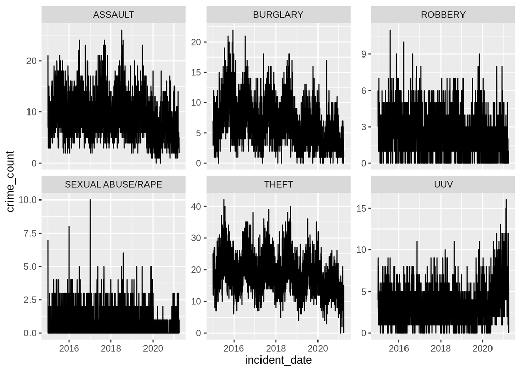

```r
# continuous sequence of dates between min and max dates in the data
# used to impute missing dates in the daily_incidents dataframe
seq_dates = seq.Date(
  from = min(daily_incidents$incident_date),
  to = max(daily_incidents$incident_date),
  by = 1
) %>%
  enframe(name = NULL, value = "incident_date")

# daily incidents with missing dates imputed with a value of 0
daily_incidents_complete = daily_incidents %>%
  split(.$incident) %>%
  map(., function(i) {
    left_join(
      x = seq_dates,
      y = i,
      by = "incident_date"
    ) %>%
      fill(incident, .direction = "downup") %>%
      replace_na(list(crime_count = 0))
  }) %>%
  bind_rows()

# visualization of daily incidents
daily_incidents_complete %>%
  ggplot(aes(x = incident_date, y = crime_count)) +
  facet_wrap(~incident, scales = "free_y") +
  geom_line()
```

# Feature engineering

The features tested in this model include:

- Date-based features for a given date (i.e. month, year, week, weekday)
- US holiday indicators

```r
# Function to "tag" features to easily include/exclude features from the model
tag_columns = function(x, prefix) {
  paste(prefix, x, sep = "_")
}

# Date-based features
date_features = daily_incidents_complete %>%
  mutate(month = lubridate::month(incident_date)) %>%
  mutate(year = lubridate::year(incident_date)) %>%
  mutate(week = lubridate::week(incident_date)) %>%
  mutate(weekday = lubridate::wday(incident_date))

# US Bank holidays
bank_holidays = tis::holidays(years = seq(2015, 2021, 1)) %>%
  enframe(name = 'Holiday', value = 'Date') %>%
  mutate(Date = as.Date(as.character(Date), '%Y%m%d')) %>%
  mutate(is_Holiday = 1)

# Concatenate date-based and holiday features
complete_features = left_join(
  date_features,
  bank_holidays,
  by = c("incident_date" = "Date")
) %>%
  replace_na(list(Holiday = "None")) %>%
  spread(Holiday, is_Holiday) %>%
  mutate(Easter = isEaster(incident_date)) %>%
  mutate(Easter = ifelse(Easter == TRUE, 1, 0)) %>%
  select(-None) %>%
  replace(is.na(.),0)

complete_features_with_tags = complete_features %>%
  rename_at(vars(month:weekday), list(~tag_columns(x = ., prefix = 'Date'))) %>%
  rename_at(vars(Christmas:Easter), list(~tag_columns(x = ., prefix = 'Holiday')))

str(complete_features_with_tags)
```

```
## tibble [13,686 × 18] (S3: tbl_df/tbl/data.frame)
##  $ incident_date       : Date[1:13686], format: "2015-01-01" "2015-01-02" ...
##  $ incident            : chr [1:13686] "ASSAULT" "ASSAULT" "ASSAULT" "ASSAULT" ...
##  $ crime_count         : num [1:13686] 21 7 10 15 10 6 3 8 5 6 ...
##  $ Date_month          : num [1:13686] 1 1 1 1 1 1 1 1 1 1 ...
##  $ Date_year           : num [1:13686] 2015 2015 2015 2015 2015 ...
##  $ Date_week           : num [1:13686] 1 1 1 1 1 1 1 2 2 2 ...
##  $ Date_weekday        : num [1:13686] 5 6 7 1 2 3 4 5 6 7 ...
##  $ Holiday_Christmas   : num [1:13686] 0 0 0 0 0 0 0 0 0 0 ...
##  $ Holiday_Columbus    : num [1:13686] 0 0 0 0 0 0 0 0 0 0 ...
##  $ Holiday_GWBirthday  : num [1:13686] 0 0 0 0 0 0 0 0 0 0 ...
##  $ Holiday_Independence: num [1:13686] 0 0 0 0 0 0 0 0 0 0 ...
##  $ Holiday_Labor       : num [1:13686] 0 0 0 0 0 0 0 0 0 0 ...
##  $ Holiday_Memorial    : num [1:13686] 0 0 0 0 0 0 0 0 0 0 ...
##  $ Holiday_MLKing      : num [1:13686] 0 0 0 0 0 0 0 0 0 0 ...
##  $ Holiday_NewYears    : num [1:13686] 1 0 0 0 0 0 0 0 0 0 ...
##  $ Holiday_Thanksgiving: num [1:13686] 0 0 0 0 0 0 0 0 0 0 ...
##  $ Holiday_Veterans    : num [1:13686] 0 0 0 0 0 0 0 0 0 0 ...
##  $ Holiday_Easter      : num [1:13686] 0 0 0 0 0 0 0 0 0 0 ...
```

# Preparing cross validation

To assess the expected performance of the forecasting model, I implemented **rolling origin cross validation** (ROCV).

```r
rocv = rolling_origin(
  data = complete_features_with_tags %>% spread(incident, crime_count),
  initial = floor(365.25*5),
  assess = 14,
  cumulative = TRUE,
  skip = 14
)
```

# Partitioning train/test splits within ROCV

Within each ROCV iteration, the following code extracts the training and testing data sets.

```r
train_test_splits = map(rocv$splits, function(split) {
  train = analysis(split) %>% gather(incident, crime_count, -contains("Date"), -contains("Holiday"))
  test = assessment(split) %>% gather(incident, crime_count, -contains("Date"), -contains("Holiday"))
  out = list(train = train, test = test)
  return(out)
})

train_test_splits[1]
```

```
## [[1]]
## [[1]]$train
## # A tibble: 10,956 x 18
##    incident_date Date_month Date_year Date_week Date_weekday Holiday_Christmas
##    <date>             <dbl>     <dbl>     <dbl>        <dbl>             <dbl>
##  1 2015-01-01             1      2015         1            5                 0
##  2 2015-01-02             1      2015         1            6                 0
##  3 2015-01-03             1      2015         1            7                 0
##  4 2015-01-04             1      2015         1            1                 0
##  5 2015-01-05             1      2015         1            2                 0
##  6 2015-01-06             1      2015         1            3                 0
##  7 2015-01-07             1      2015         1            4                 0
##  8 2015-01-08             1      2015         2            5                 0
##  9 2015-01-09             1      2015         2            6                 0
## 10 2015-01-10             1      2015         2            7                 0
## # … with 10,946 more rows, and 12 more variables: Holiday_Columbus <dbl>,
## #   Holiday_GWBirthday <dbl>, Holiday_Independence <dbl>, Holiday_Labor <dbl>,
## #   Holiday_Memorial <dbl>, Holiday_MLKing <dbl>, Holiday_NewYears <dbl>,
## #   Holiday_Thanksgiving <dbl>, Holiday_Veterans <dbl>, Holiday_Easter <dbl>,
## #   incident <chr>, crime_count <dbl>
##
## [[1]]$test
## # A tibble: 84 x 18
##    incident_date Date_month Date_year Date_week Date_weekday Holiday_Christmas
##    <date>             <dbl>     <dbl>     <dbl>        <dbl>             <dbl>
##  1 2020-01-01             1      2020         1            4                 0
##  2 2020-01-02             1      2020         1            5                 0
##  3 2020-01-03             1      2020         1            6                 0
##  4 2020-01-04             1      2020         1            7                 0
##  5 2020-01-05             1      2020         1            1                 0
##  6 2020-01-06             1      2020         1            2                 0
##  7 2020-01-07             1      2020         1            3                 0
##  8 2020-01-08             1      2020         2            4                 0
##  9 2020-01-09             1      2020         2            5                 0
## 10 2020-01-10             1      2020         2            6                 0
## # … with 74 more rows, and 12 more variables: Holiday_Columbus <dbl>,
## #   Holiday_GWBirthday <dbl>, Holiday_Independence <dbl>, Holiday_Labor <dbl>,
## #   Holiday_Memorial <dbl>, Holiday_MLKing <dbl>, Holiday_NewYears <dbl>,
## #   Holiday_Thanksgiving <dbl>, Holiday_Veterans <dbl>, Holiday_Easter <dbl>,
## #   incident <chr>, crime_count <dbl>
```

# Model Implementation

To properly evaluate the performance of the GBM, I compared it with a “simple model” based on naive predictions. Our simple model states that we’ll use the actual values from the last 14 days to predict the next 14 days. The basic idea is that the GBM model should outperfrom this simple, naive model if it is to be considered skillful.

```r
# Initialize H2O
h2o.init()
```

[output not shown]

```r
h2o.no_progress()
```

```r
rocv_models = map(train_test_splits, function(i) {

  # train/test split
  train = i$train %>% mutate(incident = as.factor(incident))
  test = i$test %>% mutate(incident = as.factor(incident))

  # convert train/test to H2OFrame format
  train_h2o = as.h2o(train)
  test_h2o = as.h2o(test)

  # list of features
  features = train %>%
    select(-crime_count, -incident_date) %>%
    colnames()

  # target variable
  target = "crime_count"

  # H2O GBM
  model = h2o.gbm(
    x = features,
    y = target,
    training_frame = train_h2o,
    validation_frame = test_h2o,
    ntrees = 50,
    learn_rate = 0.1,
    max_depth = 5,
    categorical_encoding = "AUTO",
    distribution = "poisson"
  )

  # Predictions from GBM Model
  predictions = h2o.predict(model, newdata = test_h2o) %>%
    as.vector()

  # Simple Predictions Calculation
  simple_model = train %>%
    arrange(incident, incident_date) %>%
    group_by(incident) %>%
    slice(tail(row_number(), 14)) %>%
    ungroup() %>%
    mutate(incident_date = incident_date + days(14)) %>%
    select(incident_date, incident, Simple = crime_count)

  # MASE Calculation
  MASE_by_incident = test %>%
    mutate(Predictions = predictions) %>%
    inner_join(simple_model, by = c("incident","incident_date")) %>%
    group_by(incident) %>%
    summarise(
      GBM_MAE = mean(abs(Predictions - crime_count)),
      Simple_MAE = mean(abs(Simple - crime_count))
    ) %>%
    mutate(MASE = GBM_MAE/Simple_MAE)

  #Clean out the h2o cluster.
  h2o.removeAll()

  return(MASE_by_incident)
})
```

# Expected model performance

```r
rocv_df = map2(rocv_models, seq_along(rocv_models), function(model, idx) {
  out = model %>% mutate(rocv_idx = idx)
  return(out)
}) %>%
  bind_rows()

rocv_df %>%
  group_by(incident) %>%
  filter(MASE != 'Inf') %>%
  summarise(N = n(),
            Avg_MASE = mean(MASE),
            SD_MASE = sd(MASE),
            Lower_CI = t.test(MASE)$conf.int[1],
            Upper_CI = t.test(MASE)$conf.int[2])
```

```
## # A tibble: 6 x 6
##   incident              N Avg_MASE SD_MASE Lower_CI Upper_CI
##   <fct>             <int>    <dbl>   <dbl>    <dbl>    <dbl>
## 1 ASSAULT              30    0.823   0.289    0.715    0.931
## 2 BURGLARY             30    0.856   0.238    0.768    0.945
## 3 ROBBERY              30    0.807   0.186    0.737    0.876
## 4 SEXUAL ABUSE/RAPE    29    1.57    1.04     1.17     1.96
## 5 THEFT                30    0.850   0.238    0.761    0.938
## 6 UUV                  30    0.831   0.239    0.742    0.920
```

# Conclusion

We can conclude from the final output above, that our model performed better than just our simple model in 5/6 of the incidents.

# Next Steps

Next steps in this analysis would include hyperparameter tuning and looking to see if there is any difference in crime on holidays.